# 0828FINAL

SMPARK

2024-08-28

# 0828 FINAL DATA ANALYSIS

본 내용은 2024 노동패널 공모전을 위한 Final Data Analysis의 목적으로 작성하였으며, 나중에 혹시나 R을 공부하면서 PROCESS를 돌리고 싶은 사람들을 위해 간단한 Manual을 함께 작성함. 개인적인 정리의 목적도 있고…

R이 처음이라면 R 기본서 또는 기본 강의 읽는 것 추천하지만, 요즘 다들 Python 써서 각자 용도에 맞게 하면 될듯

아 물론 Hayes의 교재인 Introduction to Mediation, Moderation, and Conditional Process Analysis에 나와있는 내용이라는 점 참고하시길!

## DATA PREPARATION

우선, process를 돌리기 위해 process macro file을 실행해야 한다. 이는 웹사이트(https://www.processmacro.org/download.html) 에서도 다운받을 수 있고, 다운받으면 process.R이라는 script를 R에서 켜서 전체선택 후 실행하면 process 함수가 밑에 나오게 될 것이다. 그러면 process 준비 끝.

여기서 사용할 기본적인 Library 몇 개를 읽고 시작하겠음.

```r
library(foreign) # 외부 파일 읽고 쓰는 관련
library(readr) # 외부 파일 읽고 쓰는 관련
library(tidyverse) # R data tidying, visualization 등에 유용
library(psych) # 심리통계에서 주로 쓰는 패키지
```

그 다음, 데이터를 받을 것인데 우리는 spss 파일을 가지고 있을 것이므로 spss파일을 읽어주어야 한다. 이후 간단하게 데이터 개수, 변수 개수, Data Format 등 체크.

```r
# klips26 이라는 데이터로 불러오기
klips26 <- read.spss('/Users/seongminpark/Desktop/klips26.sav', to.data.frame = TRUE)

# 기본적인 데이터 구조 확인하기
dim(klips26) # data 몇 개고 변수 몇 개인지 확인. 지금은 n = 9616, 변수 = 826개
str(klips26) # 전반적인 Structure 보기
glimpse(klips26) # 힐끗 보기
head(klips26, 10) # 위에서부터 10개 보여줌
```

## DATA TIDYING

패널데이터에 한해서, 변수명이 이상하게 적혀있으므로 이 점이 마음에 들지 않아 개인적으로 변수명을 변경하고 돌림. 아래는 그 과정이 나타나있음. 그리고 본 패널 데이터의 변수에 관한 정보를 마구잡이로 정리해둔 것을 기존 스크립트에서 긁어서 가져옴. 지금 과정에서 사용하지 않을 변수들이 많지만, 빼기 귀찮아서 그냥 넣었음.

```r
# jobnum1로 일자리번호 체크 가능함. 근데 해석 복잡해서 귀찮음
# jobclass : 일자리 유형. 1 = 작년 일자리 지속 / 5 = 신규 일자리
# jobtype : 임금비임금. 현재 klips data는 모두 임금근로자로 filtering 되어있음.

# worksat (직무만족도 5문항 평균) / orgflow (조직몰입도 5문항 평균)
# flexible (0 : 유연근무제 사용 X , 1 : 유연근무제 사용 O)
# spouse (0 : 미혼/이혼/사별, 1 : 배우자 있음)

# gender: 남 1 여 0
colnames(klips26)[colnames(klips26) == "p260101"] <- "gender"

# lifesat 전반적 생활 만족도: 1 (매우 만족) > 5 (매우 불만족)
colnames(klips26)[colnames(klips26) == "p266508"] <- "lifesat"
# jobsat 전반적 일자리 만족도: 1 (매우 만족) > 5 (매우 불만족)
colnames(klips26)[colnames(klips26) == "p264321"] <- "jobsat"
# happy: 0 (안 행복) > 10 (행복)
colnames(klips26)[colnames(klips26) == "pa268141"] <- "happy"
# highkids 재수생 자녀, kindkids 미취학 자녀: 1 (자녀 있음), 0 (자녀 없음)
colnames(klips26)[colnames(klips26) == "h261501"] <- "highkids"
colnames(klips26)[colnames(klips26) == "h261503"] <- "kindkids"
# worksat: 직무만족도 5문항 평균, 높을수록 만족
# orgflow: 조직몰입도 5문항 평균, 높을수록 만족

# 영역별 생활만족도(수입, 여가, 주거, 가족관계, 친인척관계, 사회적친분)
colnames(klips26)[colnames(klips26) == "p266501"] <- "sat1"
colnames(klips26)[colnames(klips26) == "p266502"] <- "sat2"
colnames(klips26)[colnames(klips26) == "p266503"] <- "sat3"
colnames(klips26)[colnames(klips26) == "p266504"] <- "sat4"
colnames(klips26)[colnames(klips26) == "p266505"] <- "sat5"
colnames(klips26)[colnames(klips26) == "p266506"] <- "sat6"

# 만나이
colnames(klips26)[colnames(klips26) == "p260107"] <- "age"
colnames(klips26)[colnames(klips26) == "p260104"] <- "birthyear"

# 영역별 직무만족도
colnames(klips26)[colnames(klips26) == "p264311"] <- "job1"
colnames(klips26)[colnames(klips26) == "p264312"] <- "job2"
colnames(klips26)[colnames(klips26) == "p264313"] <- "job3"
colnames(klips26)[colnames(klips26) == "p264314"] <- "job4"
colnames(klips26)[colnames(klips26) == "p264315"] <- "job5"
colnames(klips26)[colnames(klips26) == "p264316"] <- "job6"
colnames(klips26)[colnames(klips26) == "p264317"] <- "job7"
colnames(klips26)[colnames(klips26) == "p264318"] <- "job8"
colnames(klips26)[colnames(klips26) == "p264319"] <- "job9"

# 주관적 사회경제적 지위
colnames(klips26)[colnames(klips26) == "p266615"] <- "SES"

# 성역할 (가정 내 성역할 1-7/ 일터 성역할 8-13)
# 일터 성역할의 신뢰도가 높음. 가정 내 성역할은 선택적으로 쓸 필요가 있음
# 재코딩 아직 안 했음. 점수 높으면 매우 그렇다임
colnames(klips26)[colnames(klips26) == "p269211"] <- "gen1"
colnames(klips26)[colnames(klips26) == "p269212"] <- "gen2"
colnames(klips26)[colnames(klips26) == "p269213"] <- "gen3"
colnames(klips26)[colnames(klips26) == "p269214"] <- "gen4"
colnames(klips26)[colnames(klips26) == "p269215"] <- "gen5"
colnames(klips26)[colnames(klips26) == "p269216"] <- "gen6"
colnames(klips26)[colnames(klips26) == "p269217"] <- "gen7"
colnames(klips26)[colnames(klips26) == "p269218"] <- "gen8"
colnames(klips26)[colnames(klips26) == "p269219"] <- "gen9"
colnames(klips26)[colnames(klips26) == "p269220"] <- "gen10"
colnames(klips26)[colnames(klips26) == "p269221"] <- "gen11"
colnames(klips26)[colnames(klips26) == "p269222"] <- "gen12"
colnames(klips26)[colnames(klips26) == "p269223"] <- "gen13"

# 주당 평균 근무시간 (p261004), 주당 정규 근무시간 (p261006): 정규 근무시간 여부에 따라서 다르기 떄문에, 두 데이터를 합쳐야 변수 얻을 수 있음
colnames(klips26)[colnames(klips26) == "p261004"] <- "labtime1"
colnames(klips26)[colnames(klips26) == "p261006"] <- "labtime2"

# 직무만족도 5문항
colnames(klips26)[colnames(klips26) == "p264301"] <- "ws1"
colnames(klips26)[colnames(klips26) == "p264302"] <- "ws2"
colnames(klips26)[colnames(klips26) == "p264303"] <- "ws3"
colnames(klips26)[colnames(klips26) == "p264304"] <- "ws4"
colnames(klips26)[colnames(klips26) == "p264305"] <- "ws5"

# 성 역할 Parceling (1,8,9 / 3,10,11 / 7,12,13)
# 이건 혹시 구조방정식 돌리게 될까 해서 parceling 해 둔 것임
klips26$parcel1 <- apply(cbind(klips26$gen1, klips26$gen8, klips26$gen9), 1, mean)
klips26$parcel2 <- apply(cbind(klips26$gen3, klips26$gen10, klips26$gen11), 1, mean)
klips26$parcel3 <- apply(cbind(klips26$gen7, klips26$gen12, klips26$gen13), 1, mean)
```

또한, 역코딩이 필요한 문항은 다음과 같이 역코딩을 진행하였음.

```r
# 생활 만족도, 일자리 만족도 전부 역코딩
klips26$lifesat <- 6 - klips26$lifesat
klips26$jobsat <- 6 - klips26$jobsat

klips26$sat1 <- 6 - klips26$sat1
klips26$sat2 <- 6 - klips26$sat2
klips26$sat3 <- 6 - klips26$sat3
klips26$sat4 <- 6 - klips26$sat4
klips26$sat5 <- 6 - klips26$sat5
klips26$sat6 <- 6 - klips26$sat6

klips26$job1 <- 6 - klips26$job1
klips26$job2 <- 6 - klips26$job2
klips26$job3 <- 6 - klips26$job3
klips26$job4 <- 6 - klips26$job4
klips26$job5 <- 6 - klips26$job5
klips26$job6 <- 6 - klips26$job6
klips26$job7 <- 6 - klips26$job7
klips26$job8 <- 6 - klips26$job8
klips26$job9 <- 6 - klips26$job9

# SES 역코딩 (높을수록 지위 높게)
klips26$SES <- 7 - klips26$SES

# 역코딩을 했으므로 이제는 높은게 좋은거라고 생각하고 해석하면 됨. 계수가 웬만하면 양수
```

또한, 세대 변수를 새로 만들어야하기 때문에 생년 기준 1980년 이상이면 “MZ”, 1965년 이상이면 “X”, 그 외는 “BB” 세대로 처리하는 과정을 확인할 수 있음.

아래의 표는 각각의 세대 변수에 따른 N수의 구분을 표현한 것이다.

```r
# Generation (1번 방법))
klips26 <- klips26 %>% mutate(generation_fc =
                            ifelse(birthyear >= 1980, "MZ",
                                   ifelse(birthyear >= 1965, "X", "BB"))) %>%
  mutate(generation_fc = as.factor(generation_fc))

# Generation (2번 방법))
klips26 <- klips26 %>% mutate(generation =
                            ifelse(birthyear >= 1980, 1,
                                   ifelse(birthyear >= 1965, 2, 3)))

# Generation_MZ_Others: Generation 값이 3인 MZ의 경우 1로, 나머지는 0으로 코딩
klips26 <- klips26 %>% mutate(generation_mzo = ifelse(generation == 3, 1, 0))

# 세대 별 몇 명인지 체크
table(klips26$generation); table(klips26$generation_fc); table(klips26$generation_mzo)
```

```
##
##    1    2    3
## 3894 3395 2327
```

```
##
##   BB   MZ    X
## 2327 3894 3395
```

```
##
##    0    1
## 7289 2327
```

다음은 큰 용량의 데이터에서 우리가 사용하고자 하는 변수들만 포함한 데이터로 만드는 과정이다. 현재 논의되고 있는 변수들이 정해져있는 만큼, 해당 변수들만을 포함하고 있는 파일을 하나 새로 생성하고자 한다. 물론 그냥 돌려도 상관 없으나, 이렇게 하는 과정을 소개하는 차원에서.

```r
# 총 52개의 변수만 필터링

klips26_filt <- klips26 %>%
  select(sat1, sat2, sat3, sat4, sat5, sat6, lifesat, orgflow,
         ws1, ws2, ws3, ws4, ws5, worksat,
         job1, job2, job3, job4, job5, job6, job7, job8, job9, jobsat,
         gen1, gen2, gen3, gen4, gen5, gen6, gen7, gen8, gen9, gen10, gen11, gen12, gen13,
         gen_avg, parcel1, parcel2, parcel3,
         gender, spouse, age, birthyear, SES, flexible, labtime1, labtime2,
         generation, generation_fc, generation_mzo)
```

결측값을 체크해보자. 각 변수 당 결측값이 몇 개씩 있을까나.

```r
# 결측값 개수 세기.

colSums(is.na(klips26_filt))
```

```
##           sat1           sat2           sat3           sat4           sat5
##              0              0              0              0              0
##           sat6        lifesat        orgflow            ws1            ws2
##              0              0              0              0              0
##            ws3            ws4            ws5        worksat           job1
##              0              0              0              0              0
##           job2           job3           job4           job5           job6
##              0              0              0              0              0
##           job7           job8           job9         jobsat           gen1
##              0              0              0              0              0
##           gen2           gen3           gen4           gen5           gen6
##              0              0              0              0              0
##           gen7           gen8           gen9          gen10          gen11
##              0              0              0              0              0
##          gen12          gen13        gen_avg        parcel1        parcel2
##              0              0              0              0              0
##        parcel3         gender         spouse            age      birthyear
##              0              0              0              0              0
##            SES       flexible       labtime1       labtime2     generation
##              0              0           8654            962              0
##  generation_fc generation_mzo
##              0              0
```

labtime 변수에만 결측값이 가득하다. 뭔가 보기 싫으니까 저 두 변수는 없애줘야겠다.

```r
klips26_filt <- klips26_filt %>% select(-labtime1, -labtime2)
colSums(is.na(klips26_filt))
```

```
##           sat1           sat2           sat3           sat4           sat5
##              0              0              0              0              0
##           sat6        lifesat        orgflow            ws1            ws2
##              0              0              0              0              0
##            ws3            ws4            ws5        worksat           job1
##              0              0              0              0              0
##           job2           job3           job4           job5           job6
##              0              0              0              0              0
##           job7           job8           job9         jobsat           gen1
##              0              0              0              0              0
##           gen2           gen3           gen4           gen5           gen6
##              0              0              0              0              0
##           gen7           gen8           gen9          gen10          gen11
##              0              0              0              0              0
##          gen12          gen13        gen_avg        parcel1        parcel2
##              0              0              0              0              0
##        parcel3         gender         spouse            age      birthyear
##              0              0              0              0              0
##            SES       flexible     generation  generation_fc generation_mzo
##              0              0              0              0              0
```

없어진 것을 확인할 수 있다. 아이 기분좋아

기존에 있던 결측값들을 새로운 값으로 대체한다던지(이를테면 -999), 그런 방법이 여러개가 있지만 여기서는 기술하지 않겠음. 검색하면 많이 나오기도 하고 어짜피 위대하신 ChatGPT 아래 모두 평등하다…

## DATA ANALYSIS USING PROCESS

자, 본격적으로 PROCESS를 돌려보자. 기본적인 코드 형식은 SPSS와 크게 다르지 않지만, 미묘한 차이가 존재한다.

> **process(데이터명, y = “종속변수”, m = “매개변수”“, x =”독립변수”, w = “조절변수”, model = 모델번호, seed = 시드번호)**

우선, 데이터를 지정해야한다는 점. 그리고 큰 따옴표를 변수명에 걸어주어야 하는 차이가 있다. 원래 액셀도 그렇고 문자열에는 큰따옴표 거는 게 정석이기 때문이다. 이외에도 변수가 여러 개면 아래와 같이 c()로 묶어서 순서대로 나열한다. 특히, Serial Mediation이면 순서 중요하다.

### NOTION MODEL 10

바로 가장 최근에 내가 돌렸던 모형을 돌려보겠다. 노션 기준 모형 10번에 해당한다. 해석은 귀찮아서 아직 하지 않았는데, 일단 다른 모델에 대한 해석과 comment를 먼저 하기 위해서…

아 그리고 y변수를 ‘전반적일자리만족도’ 로 돌려놨길래 ‘직무만족도 평균’ 으로 바꿨음

```r
process(klips26_filt, y = "worksat", m = c("gen_avg","sat4"), x = "generation", w = "gender", mcx=1, model = 92, plot = 1, seed = 1234)
```

#### 기초 변수 정보 확인하기

```
********************* PROCESS for R Version 4.3.1 *********************

           Written by Andrew F. Hayes, Ph.D.  www.afhayes.com
   Documentation available in Hayes (2022). www.guilford.com/p/hayes3


Model : 92
    Y : worksat
    X : generation
   M1 : gen_avg
   M2 : sat4
    W : gender

Sample size: 9616

Custom seed: 1234

Coding of categorical X variable for analysis:
  generation        X1        X2
      1.0000    0.0000    0.0000
      2.0000    1.0000    0.0000
      3.0000    0.0000    1.0000
```

#### **1. 첫 번째 회귀식**

**성 관념 인식** ~ MZ_X + MZ_BB + 성별 + MZ_X*성별 + MZ_BB*성별

```
***********************************************************************
Outcome Variable: gen_avg

Model Summary:
          R      R-sq       MSE         F       df1       df2         p
     0.2564    0.0657    0.3472  135.2450    5.0000 9610.0000    0.0000

Model:
             coeff        se         t         p      LLCI      ULCI
constant    1.8255    0.0142  128.4471    0.0000    1.7976    1.8533
X1          0.1285    0.0212    6.0713    0.0000    0.0870    0.1700
X2          0.3808    0.0224   16.9848    0.0000    0.3368    0.4247
gender      0.2556    0.0190   13.4436    0.0000    0.2184    0.2929
Int_1      -0.0250    0.0280   -0.8931    0.3718   -0.0798    0.0299
Int_2      -0.1540    0.0310   -4.9734    0.0000   -0.2147   -0.0933

Product terms key:
Int_1  :  X1  x  gender
Int_2  :  X2  x  gender

Test(s) of highest order unconditional interaction(s):
      R2-chng         F       df1       df2         p
X*W    0.0026   13.2153    2.0000 9610.0000    0.0000
----------
Focal predictor: generation (X)
      Moderator: gender (W)

Conditional effects of the focal predictor at values of the moderator(s):

Moderator value(s):

gender    0.0000

      effect        se         t         p      LLCI      ULCI
X1    0.1285    0.0212    6.0713    0.0000    0.0870    0.1700
X2    0.3808    0.0224   16.9848    0.0000    0.3368    0.4247

Test of equality of conditional means
          F       df1       df2         p
   145.0631    2.0000 9610.0000    0.0000

Estimated conditional means being compared:
  generation   gen_avg
      1.0000    1.8255
      2.0000    1.9540
      3.0000    2.2063
----------
Moderator value(s):

gender    1.0000

      effect        se         t         p      LLCI      ULCI
X1    0.1035    0.0183    5.6572    0.0000    0.0676    0.1394
X2    0.2268    0.0214   10.6224    0.0000    0.1849    0.2687

Test of equality of conditional means
          F       df1       df2         p
    57.4574    2.0000 9610.0000    0.0000

Estimated conditional means being compared:
  generation   gen_avg
      1.0000    2.0811
      2.0000    2.1846
      3.0000    2.3079

Data for visualizing the conditional effect of the focal predictor:
  generation    gender   gen_avg
      1.0000    0.0000    1.8255
      2.0000    0.0000    1.9540
      3.0000    0.0000    2.2063
      1.0000    1.0000    2.0811
      2.0000    1.0000    2.1846
      3.0000    1.0000    2.3079
```

#### 2. 두 번째 회귀식

**가족관계 만족도** ~ MZ_X + MZ_BB + 성 관념 인식 + 성별 + MZ_X*성별 + MZ_BB*성별 + 성 관념 인식*성별

```
***********************************************************************
Outcome Variable: sat4

Model Summary:
          R      R-sq       MSE         F       df1       df2         p
     0.1498    0.0224    0.3502   31.5160    7.0000 9608.0000    0.0000

Model:
             coeff        se         t         p      LLCI      ULCI
constant    3.9967    0.0320  124.8629    0.0000    3.9340    4.0595
X1         -0.0440    0.0214   -2.0610    0.0393   -0.0859   -0.0022
X2         -0.1528    0.0233   -6.5603    0.0000   -0.1985   -0.1072
gen_avg    -0.1164    0.0157   -7.4191    0.0000   -0.1472   -0.0857
gender     -0.0072    0.0445   -0.1628    0.8707   -0.0944    0.0799
Int_1      -0.0006    0.0282   -0.0227    0.9819   -0.0559    0.0546
Int_2       0.0572    0.0318    1.7990    0.0721   -0.0051    0.1196
Int_3       0.0212    0.0207    1.0227    0.3065   -0.0194    0.0618

Product terms key:
Int_1  :  X1  x  gender
Int_2  :  X2  x  gender
Int_3  :  gen_avg  x  gender

Test(s) of highest order unconditional interaction(s):
       R2-chng         F       df1       df2         p
X*W     0.0004    1.9959    2.0000 9608.0000    0.1360
M1*W    0.0001    1.0458    1.0000 9608.0000    0.3065
----------
Focal predictor: generation (X)
      Moderator: gender (W)

Data for visualizing the conditional effect of the focal predictor:
  generation    gender      sat4
      1.0000    0.0000    3.7545
      2.0000    0.0000    3.7104
      3.0000    0.0000    3.6016
      1.0000    1.0000    3.7913
      2.0000    1.0000    3.7467
      3.0000    1.0000    3.6957
----------
Focal predictor: gen_avg (M1)
      Moderator: gender (W)

Data for visualizing the conditional effect of the focal predictor:
    gen_avg    gender      sat4
     1.3333    0.0000    3.7890
     2.1111    0.0000    3.6984
     2.6667    0.0000    3.6337
     1.3333    1.0000    3.8236
     2.1111    1.0000    3.7495
     2.6667    1.0000    3.6966
```

#### 3. 세 번째 회귀식

직무만족도 평균 ~ MZ_X + MZ_BB + 성 관념 인식 + 가족관계 만족도 + 성별 + MZ_X*성별 + MZ_BB*성별 + 성 관념 인식*성별 + 가족관계 만족도*성별

```
***********************************************************************
Outcome Variable: worksat

Model Summary:
          R      R-sq       MSE         F       df1       df2         p
     0.3391    0.1150    0.2638  138.6891    9.0000 9606.0000    0.0000

Model:
             coeff        se         t         p      LLCI      ULCI
constant    2.6001    0.0601   43.2590    0.0000    2.4823    2.7179
X1          0.0225    0.0185    1.2111    0.2259   -0.0139    0.0588
X2          0.0174    0.0203    0.8565    0.3918   -0.0224    0.0572
gen_avg    -0.0430    0.0137   -3.1369    0.0017   -0.0699   -0.0161
sat4        0.2947    0.0133   22.1011    0.0000    0.2686    0.3209
gender     -0.1393    0.0810   -1.7192    0.0856   -0.2980    0.0195
Int_1      -0.0203    0.0245   -0.8282    0.4076   -0.0683    0.0277
Int_2      -0.0343    0.0277   -1.2393    0.2153   -0.0886    0.0200
Int_3       0.0426    0.0181    2.3571    0.0184    0.0072    0.0781
Int_4       0.0188    0.0178    1.0518    0.2929   -0.0162    0.0537

Product terms key:
Int_1  :  X1  x  gender
Int_2  :  X2  x  gender
Int_3  :  gen_avg  x  gender
Int_4  :  sat4  x  gender

Test(s) of highest order unconditional interaction(s):
       R2-chng         F       df1       df2         p
X*W     0.0002    0.8232    2.0000 9606.0000    0.4391
M1*W    0.0005    5.5557    1.0000 9606.0000    0.0184
M2*W    0.0001    1.1062    1.0000 9606.0000    0.2929
----------
Focal predictor: generation (X)
      Moderator: gender (W)

Data for visualizing the conditional effect of the focal predictor:
  generation    gender   worksat
      1.0000    0.0000    3.6101
      2.0000    0.0000    3.6326
      3.0000    0.0000    3.6275
      1.0000    1.0000    3.6295
      2.0000    1.0000    3.6317
      3.0000    1.0000    3.6126
----------
Focal predictor: gen_avg (M1)
      Moderator: gender (W)

Conditional effects of the focal predictor at values of the moderator(s):
     gender    effect        se         t         p      LLCI      ULCI
     0.0000   -0.0430    0.0137   -3.1369    0.0017   -0.0699   -0.0161
     1.0000   -0.0004    0.0118   -0.0325    0.9741   -0.0235    0.0227

Data for visualizing the conditional effect of the focal predictor:
    gen_avg    gender   worksat
     1.3333    0.0000    3.6544
     2.1111    0.0000    3.6210
     2.6667    0.0000    3.5971
     1.3333    1.0000    3.6265
     2.1111    1.0000    3.6262
     2.6667    1.0000    3.6260
----------
Focal predictor: sat4 (M2)
      Moderator: gender (W)

Data for visualizing the conditional effect of the focal predictor:
       sat4    gender   worksat
     3.0000    0.0000    3.4070
     4.0000    0.0000    3.7018
     4.0000    0.0000    3.7018
     3.0000    1.0000    3.3972
     4.0000    1.0000    3.7108
     4.0000    1.0000    3.7108
```

#### Bootstrapping을 통한 직접효과와 간접효과의 비교

```
Bootstrapping progress:
  |>>>>>>>>>>>>>>>>>>>>>>>>>>>>>>>>>>>>>>>>>>>>>>>>>>>>>>>>>>>>>>| 100%

**************** DIRECT AND INDIRECT EFFECTS OF X ON Y ****************

Relative conditional direct effects of X on Y:
      gender    effect        se         t         p      LLCI      ULCI
X1    0.0000    0.0225    0.0185    1.2111    0.2259   -0.0139    0.0588
X1    1.0000    0.0022    0.0160    0.1355    0.8922   -0.0292    0.0335
X2    0.0000    0.0174    0.0203    0.8565    0.3918   -0.0224    0.0572
X2    1.0000   -0.0169    0.0188   -0.8991    0.3686   -0.0539    0.0200

Relative conditional indirect effects of X on Y:

INDIRECT EFFECT:

generation    ->    gen_avg    ->    worksat

      gender    Effect    BootSE  BootLLCI  BootULCI
X1    0.0000   -0.0055    0.0021   -0.0099   -0.0018
X1    1.0000   -0.0000    0.0012   -0.0024    0.0024

     Index of moderated mediation
     (differences beween conditional indirect effects):
           Index    BootSE  BootLLCI  BootULCI
gender    0.0055    0.0024    0.0011    0.0104
      gender    Effect    BootSE  BootLLCI  BootULCI
X2    0.0000   -0.0164    0.0055   -0.0274   -0.0056
X2    1.0000   -0.0001    0.0027   -0.0053    0.0052

     Index of moderated mediation
     (differences beween conditional indirect effects):
           Index    BootSE  BootLLCI  BootULCI
gender    0.0163    0.0061    0.0044    0.0282

INDIRECT EFFECT:

generation    ->    sat4    ->    worksat

      gender    Effect    BootSE  BootLLCI  BootULCI
```

[output cut: 27 more lines]

```
gender    0.0013    0.0012   -0.0009    0.0037
      gender    Effect    BootSE  BootLLCI  BootULCI
X2    0.0000   -0.0131    0.0020   -0.0172   -0.0093
X2    1.0000   -0.0068    0.0011   -0.0091   -0.0047

     Index of moderated mediation
     (differences beween conditional indirect effects):
           Index    BootSE  BootLLCI  BootULCI
gender    0.0063    0.0023    0.0019    0.0109

******************** ANALYSIS NOTES AND ERRORS ************************

Level of confidence for all confidence intervals in output: 95

Number of bootstraps for percentile bootstrap confidence intervals: 5000
```

근데 돌리고 나서 보니 가족관계 만족도가 다소 보통~만족함에 편향되어 있는 것 같기도 하다.

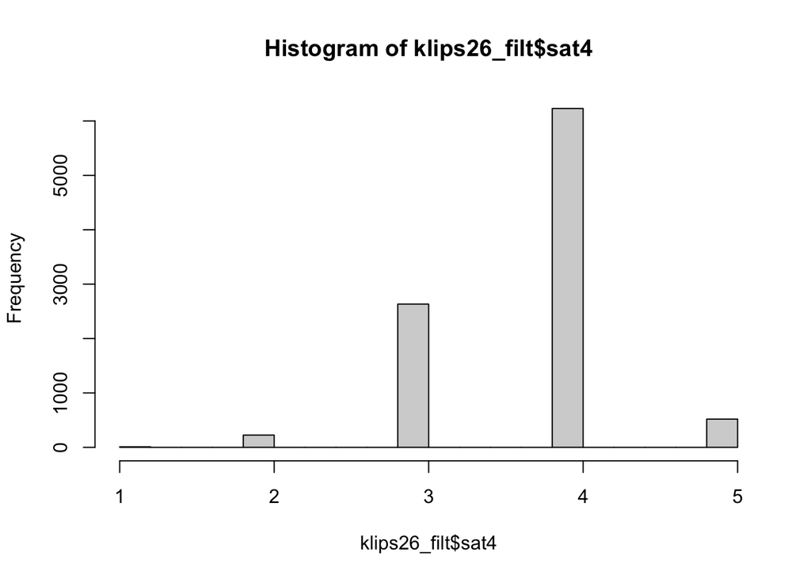

```r
# 히스토그램 그려보기
hist(klips26_filt$sat4)
```

```r
# 누적분포 느낌으로 쭉 그려보면 하위 5%부터 당장 3을 찍고 있다.
quantile(klips26_filt$sat4, probs = seq(0, 1, 0.05))
```

```
##   0%   5%  10%  15%  20%  25%  30%  35%  40%  45%  50%  55%  60%  65%  70%  75%
##    1    3    3    3    3    3    4    4    4    4    4    4    4    4    4    4
##  80%  85%  90%  95% 100%
##    4    4    4    5    5
```

```r
# 도수 확인하기
table(klips26_filt$sat4)
```

```
##
##    1    2    3    4    5
##   10  225 2633 6229  519
```

그러하다. 1을 찍는 사람은 10명, 2를 찍는 사람은 225명에 불과하다. 가족 관계는 다들 보통 이상인갑다.

따라서, 가족관계 만족도를 보는 것은 (적어도 한국 사회에서는) 그닥 효과적이지 않은 변수일수도 있겠다.

### ANOTHER MODEL

기윤이가 카톡방에서 제안한 모형을 돌려보겠다.

```r
process(klips26_filt, y="worksat", x="gen_avg", m="orgflow", w="generation", mcw=1, model=8, plot=1, seed=1234)
```

#### 기초 변수 정보

```
********************* PROCESS for R Version 4.3.1 *********************

           Written by Andrew F. Hayes, Ph.D.  www.afhayes.com
   Documentation available in Hayes (2022). www.guilford.com/p/hayes3


Model : 8
    Y : worksat
    X : gen_avg
    M : orgflow
    W : generation

Sample size: 9616

Custom seed: 1234

Coding of categorical W variable for analysis:
  generation        W1        W2
      1.0000    0.0000    0.0000
      2.0000    1.0000    0.0000
      3.0000    0.0000    1.0000
```

#### 1. 첫 번째 회귀식

조직몰입도 평균 ~ 성 관념 인식 + MZ_X + MZ_BB + 성 관념 인식*MZ_X + 성 관념 인식*MZ_BB

```
***********************************************************************
Outcome Variable: orgflow

Model Summary:
          R      R-sq       MSE         F       df1       df2         p
     0.0890    0.0079    0.3129   15.3589    5.0000 9610.0000    0.0000

Model:
             coeff        se         t         p      LLCI      ULCI
constant    3.5071    0.0303  115.6471    0.0000    3.4477    3.5665
gen_avg     0.0147    0.0147    0.9960    0.3193   -0.0142    0.0435
W1         -0.0016    0.0464   -0.0341    0.9728   -0.0926    0.0894
W2          0.0574    0.0550    1.0438    0.2966   -0.0504    0.1651
Int_1      -0.0083    0.0219   -0.3801    0.7038   -0.0512    0.0346
Int_2      -0.0779    0.0245   -3.1729    0.0015   -0.1260   -0.0298

Product terms key:
Int_1  :  gen_avg  x  W1
Int_2  :  gen_avg  x  W2

Test(s) of highest order unconditional interaction(s):
      R2-chng         F       df1       df2         p
X*W    0.0011    5.5171    2.0000 9610.0000    0.0040
----------
Focal predictor: gen_avg (X)
      Moderator: generation (W)

Conditional effects of the focal predictor at values of the moderator(s):
  generation    effect        se         t         p      LLCI      ULCI
      1.0000    0.0147    0.0147    0.9960    0.3193   -0.0142    0.0435
      2.0000    0.0063    0.0162    0.3918    0.6952   -0.0254    0.0381
      3.0000   -0.0632    0.0196   -3.2185    0.0013   -0.1017   -0.0247

Data for visualizing the conditional effect of the focal predictor:
    gen_avg generation   orgflow
     1.3333     1.0000    3.5266
     2.1111     1.0000    3.5380
     2.6667     1.0000    3.5462
     1.3333     2.0000    3.5140
     2.1111     2.0000    3.5189
     2.6667     2.0000    3.5224
     1.3333     3.0000    3.4802
     2.1111     3.0000    3.4310
     2.6667     3.0000    3.3959
```

위의 해석과 관련하여, 이를 직관적으로 이해할 수 있도록 Plot을 그려보도록 한다. Plot을 그리고 싶으면 위의 PROCESS Syntax에 Plot=1을 추가하고, ‘Data for Visualizing the conditional effect of the focal predictor’ 부분의 숫자를 잘 활용하면 된다.

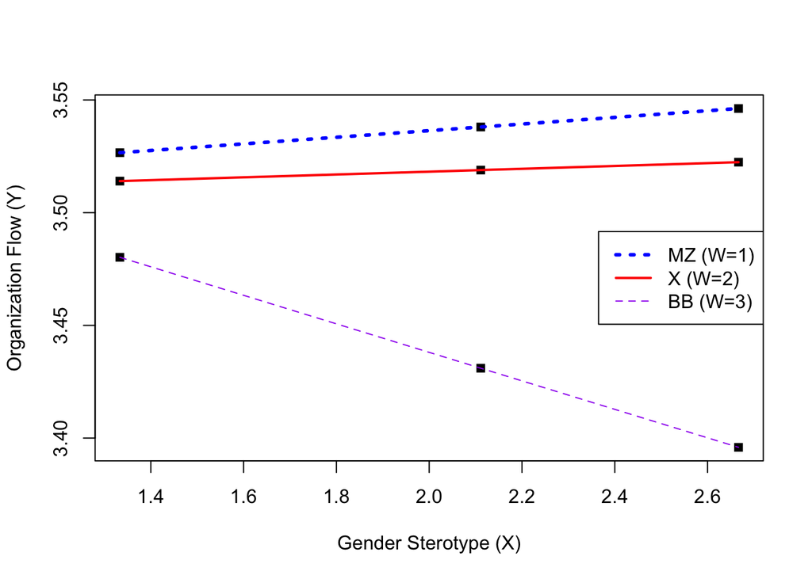

```r
x<-c(1.3333, 2.1111, 2.6667, 1.3333, 2.1111, 2.6667, 1.3333, 2.1111, 2.6667)
w<-c(1,1,1,2,2,2,3,3,3)
y<-c(3.5266, 3.5380, 3.5462, 3.5140, 3.5189, 3.5224, 3.4802, 3.4310, 3.3959)
plot(y=y,x=x,pch=15,col="black",xlab="Gender Sterotype (X)",
ylab="Organization Flow (Y)")
legend.txt<-c("MZ (W=1)","X (W=2)", "BB (W=3)")
legend("right",legend=legend.txt,lty=c(3,1,2),lwd=c(3,2,1), col=c("blue","red", "purple"))
lines(x[w==1],y[w==1],lty=3,lwd=3,col="blue") # W=0일 때 X와 Y를 이음
lines(x[w==2],y[w==2],lty=1,lwd=2,col="red") # W=1일 때 X와 Y를 이음
lines(x[w==3],y[w==3],lty=2,lwd=1,col="purple")
```

#### 2. 두 번째 회귀식

직무만족도 평균 ~ 성 관념 인식 + 조직몰입도 + MZ_X + MZ_BB + 성 관념 인식*MZ_X + 성 관념 인식*MZ_BB

```
***********************************************************************
Outcome Variable: worksat

Model Summary:
          R      R-sq       MSE         F       df1       df2         p
     0.7593    0.5765    0.1262 2180.1324    6.0000 9609.0000    0.0000

Model:
             coeff        se         t         p      LLCI      ULCI
constant    1.0776    0.0298   36.1834    0.0000    1.0192    1.1360
gen_avg    -0.0202    0.0093   -2.1567    0.0311   -0.0385   -0.0018
orgflow     0.7369    0.0065  113.7569    0.0000    0.7242    0.7496
W1          0.0885    0.0295    3.0028    0.0027    0.0307    0.1463
W2          0.1219    0.0349    3.4940    0.0005    0.0535    0.1904
Int_1      -0.0393    0.0139   -2.8275    0.0047   -0.0665   -0.0121
Int_2      -0.0390    0.0156   -2.4999    0.0124   -0.0696   -0.0084

Product terms key:
Int_1  :  gen_avg  x  W1
Int_2  :  gen_avg  x  W2

Test(s) of highest order unconditional interaction(s):
      R2-chng         F       df1       df2         p
X*W    0.0004    5.1012    2.0000 9609.0000    0.0061
----------
Focal predictor: gen_avg (X)
      Moderator: generation (W)

Conditional effects of the focal predictor at values of the moderator(s):
  generation    effect        se         t         p      LLCI      ULCI
      1.0000   -0.0202    0.0093   -2.1567    0.0311   -0.0385   -0.0018
      2.0000   -0.0594    0.0103   -5.7823    0.0000   -0.0796   -0.0393
      3.0000   -0.0591    0.0125   -4.7392    0.0000   -0.0836   -0.0347

Data for visualizing the conditional effect of the focal predictor:
    gen_avg generation   worksat
     1.3333     1.0000    3.6315
     2.1111     1.0000    3.6158
     2.6667     1.0000    3.6046
     1.3333     2.0000    3.6676
     2.1111     2.0000    3.6214
     2.6667     2.0000    3.5883
     1.3333     3.0000    3.7014
     2.1111     3.0000    3.6554
     2.6667     3.0000    3.6226
```

> 해석 Guide
> - 모든 상호작용 효과가 유의한데, 이는 성 관념 인식에 따른 직무만족도 변화가 MZ세대와 X, BB세대 간에 상이하게 나타난다는 뜻.
> - 일반적으로는 성 관념 인식이 평등할수록(-) 직무 만족도가 증가(+)하는데, 여기서 상호작용 효과 계수가 둘다 (-) 이므로 Synergy Effect 발생, 즉 X세대, BB세대일수록 심화되는 정도가 가파르다.
> - 이와는 별개로, 조직몰입도가 높으면 직무만족도가 높다.

역시 아래 Plot을 확인하라.

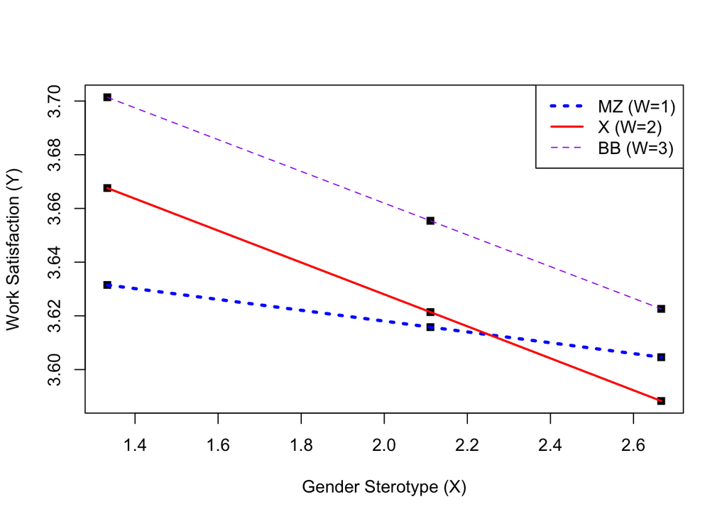

```r
x<-c(1.3333, 2.1111, 2.6667, 1.3333, 2.1111, 2.6667, 1.3333, 2.1111, 2.6667)
w<-c(1,1,1,2,2,2,3,3,3)
y<-c(3.6315, 3.6158, 3.6046, 3.6676, 3.6214, 3.5883, 3.7014, 3.6554, 3.6226)
plot(y=y,x=x,pch=15,col="black",xlab="Gender Sterotype (X)",
ylab= "Work Satisfaction (Y)")
legend.txt<-c("MZ (W=1)","X (W=2)", "BB (W=3)")
legend("topright",legend=legend.txt,lty=c(3,1,2),lwd=c(3,2,1), col=c("blue","red", "purple"))
lines(x[w==1],y[w==1],lty=3,lwd=3,col="blue") # W=0일 때 X와 Y를 이음
lines(x[w==2],y[w==2],lty=1,lwd=2,col="red") # W=1일 때 X와 Y를 이음
lines(x[w==3],y[w==3],lty=2,lwd=1,col="purple")
```

#### Bootstrapping을 통한 직접효과와 간접효과의 비교

```
Bootstrapping progress:
  |>>>>>>>>>>>>>>>>>>>>>>>>>>>>>>>>>>>>>>>>>>>>>>>>>>>>>>>>>>>>>>| 100%

**************** DIRECT AND INDIRECT EFFECTS OF X ON Y ****************

Conditional direct effect(s) of X on Y:
  generation    effect        se         t         p      LLCI      ULCI
      1.0000   -0.0202    0.0093   -2.1567    0.0311   -0.0385   -0.0018
      2.0000   -0.0594    0.0103   -5.7823    0.0000   -0.0796   -0.0393
      3.0000   -0.0591    0.0125   -4.7392    0.0000   -0.0836   -0.0347

Conditional indirect effects of X on Y:

INDIRECT EFFECT:

gen_avg    ->    orgflow    ->    worksat

  generation    Effect    BootSE  BootLLCI  BootULCI
      1.0000    0.0108    0.0111   -0.0111    0.0327
      2.0000    0.0047    0.0120   -0.0185    0.0285
      3.0000   -0.0466    0.0154   -0.0770   -0.0158

     Index of moderated mediation
     (differences beween conditional indirect effects):
       Index    BootSE  BootLLCI  BootULCI
W1   -0.0061    0.0163   -0.0380    0.0266
W2   -0.0574    0.0188   -0.0937   -0.0210

******************** ANALYSIS NOTES AND ERRORS ************************

Level of confidence for all confidence intervals in output: 95

Number of bootstraps for percentile bootstrap confidence intervals: 5000
```

> **해석 Guide**
> - 매개된 조절 효과의 경우 조졀변수에 따라 매개효과가 달라지는가를 의미하므로 이를 조건부 간접효과, 영어로 Conditional Indierct Effect라고 부른다. 여기서 Index of Moderated Mediation을 체크하면 조절된 매개효과가 각 조절변수 범주에 대해 유의한지를 확인할 수 있다.
> - 보아하니 W1는 유의하지 않고 W2는 유의하다. 즉 MZ와 BB의 차이만 유의하다고 보면 되겠다.이는 바로 위에 있는 세대 범주 별 Effect 계수의 차이를 통해서 확인할 수 있다. 1-2 차이는 0.0061, 1-3차이는 0.0574이다. 이는 아래 Index와 동일한 결과이다. 저 기울기가 유의한 차이가 있냐 없냐가 바로 조절된 매개효과의 유의성 판단 근거이다.
> - 간접효과를 보면 한편, BB세대의 간접효과만 유의한 것을 확인할 수 있다. 이는 X세대와 MZ세대는 위의 첫 번째 회귀식 결과에서도 확인할 수 있듯 성 관념 인식이 조직몰입도에 유의한 영향을 미치지 않았던 것과 상응한다(저게 유의하지 않아버리면 매개효과도 거의 없음. 이는 Baron & Kenny (1986)의 Process에서도 언급. 물론 이걸 reference로 쓰지는 않을 거지만)
> - 한편, BB세대의 경우 성 관념 인식이 평등할수록(-) 조직몰입도가 증가하고(+) 이는 곧 직무만족도의 증가(+)로 이어진다. 정리하자면, BB세대의 경우 간접, 직접효과 모두 유의하므로 부분매개(Partial Mediation Effert). X세대와 MZ세대는 유의한 매개효과가 없었다.

### NEW MODEL : ANOTHER MODEL WITH GENDER

위의 모델에 성별 조절효과를 추가하는 방안을 고민해보자. 성 관념 인식의 차이를 논하는데 성별 변수가 없으면 그냥 논리가 부족하다고밖에 볼 수 없다고 개인적으로 생각한다. 성별 관해서 유의하게 나오지 않더라도.

일단 넣는다. 유의하지 않으면 그냥 남녀간의 차이가 없었다 하고 해석해버리면 그만이다.

```r
process(klips26_filt, y="worksat", x="gen_avg", m="orgflow", w="generation", z="gender", mcw=1, model=12, plot=1, seed=1234)
```

#### 기초 변수 정보

```
********************* PROCESS for R Version 4.3.1 *********************

           Written by Andrew F. Hayes, Ph.D.  www.afhayes.com
   Documentation available in Hayes (2022). www.guilford.com/p/hayes3


Model : 12
    Y : worksat
    X : gen_avg
    M : orgflow
    W : generation
    Z : gender

Sample size: 9616

Custom seed: 1234

Coding of categorical W variable for analysis:
  generation        W1        W2
      1.0000    0.0000    0.0000
      2.0000    1.0000    0.0000
      3.0000    0.0000    1.0000
```

#### 1. 첫 번째 회귀식

M ~ X + W1 + W2 + XW1 + XW2 + Z + XZ + W1Z + W2Z + XW1Z + XW2Z

```
***********************************************************************
Outcome Variable: orgflow

Model Summary:
          R      R-sq       MSE         F       df1       df2         p
     0.0970    0.0094    0.3126    8.2987   11.0000 9604.0000    0.0000

Model:
             coeff        se         t         p      LLCI      ULCI
constant    3.5074    0.0449   78.1125    0.0000    3.4194    3.5954
gen_avg     0.0058    0.0235    0.2463    0.8055   -0.0402    0.0518
W1          0.0891    0.0693    1.2846    0.1990   -0.0468    0.2249
W2          0.0781    0.0787    0.9924    0.3210   -0.0762    0.2325
Int_1      -0.0564    0.0350   -1.6123    0.1069   -0.1249    0.0122
Int_2      -0.0849    0.0368   -2.3083    0.0210   -0.1571   -0.0128
gender      0.0172    0.0618    0.2777    0.7813   -0.1040    0.1384
Int_3       0.0065    0.0306    0.2128    0.8315   -0.0534    0.0664
Int_4      -0.1570    0.0946   -1.6594    0.0971   -0.3424    0.0285
Int_5      -0.0496    0.1108   -0.4481    0.6541   -0.2668    0.1675
Int_6       0.0794    0.0454    1.7484    0.0804   -0.0096    0.1685
Int_7       0.0204    0.0499    0.4083    0.6830   -0.0774    0.1182

Product terms key:
Int_1  :  gen_avg  x  W1
Int_2  :  gen_avg  x  W2
Int_3  :  gen_avg  x  gender
Int_4  :  W1  x  gender
Int_5  :  W2  x  gender
Int_6  :  gen_avg  x  W1  x  gender
Int_7  :  gen_avg  x  W2  x  gender

Test(s) of highest order unconditional interaction(s):
        R2-chng         F       df1       df2         p
X*W*Z    0.0003    1.5873    2.0000 9604.0000    0.2045
----------
Focal predictor: gen_avg (X)
      Moderator: generation (W)
      Moderator: gender (Z)

Data for visualizing the conditional effect of the focal predictor:
    gen_avg generation    gender   orgflow
     1.3333     1.0000    0.0000    3.5151
     2.1111     1.0000    0.0000    3.5196
     2.6667     1.0000    0.0000    3.5228
     1.3333     1.0000    1.0000    3.5410
     2.1111     1.0000    1.0000    3.5505
     2.6667     1.0000    1.0000    3.5574
     1.3333     2.0000    0.0000    3.5290
     2.1111     2.0000    0.0000    3.4896
     2.6667     2.0000    0.0000    3.4615
     1.3333     2.0000    1.0000    3.5038
     2.1111     2.0000    1.0000    3.5312
     2.6667     2.0000    1.0000    3.5509
     1.3333     3.0000    0.0000    3.4800
     2.1111     3.0000    0.0000    3.4184
     2.6667     3.0000    0.0000    3.3745
     1.3333     3.0000    1.0000    3.4834
     2.1111     3.0000    1.0000    3.4427
     2.6667     3.0000    1.0000    3.4137
```

> **해석 Guide**
> - 우선, Moderated Moderation의 경우 상호작용 항이 세 변수의 곱으로 나오기 때문에, 최고차항의 상호작용 항이 유의한지를 가장 먼저 확인하고, 그 다음 두 변수의 곱 순서대로 유의성을 따지면 된다.
> - 상호작용 항이 싹다 유의하지 않으면 그다음 단일 변수의 계수 체크.어짜피 위의 ANOTHER MODEL에서도 Int_2를 제외하고 싹 다 유의하지 않았음.
> - 즉 성 관념 인식 - 조직몰입도로 갈 때 성차가 없었다고 이야기하면 그만. 그래도 Int_2는 여전히 유의하므로 이전 모델과 같은 방식으로의 해석이 가능하다.

Plot을 그려보자. 이 경우 Z변수인 성별을 기준으로 두 개 따로 나누어 그림을 그리시면 되겠다.

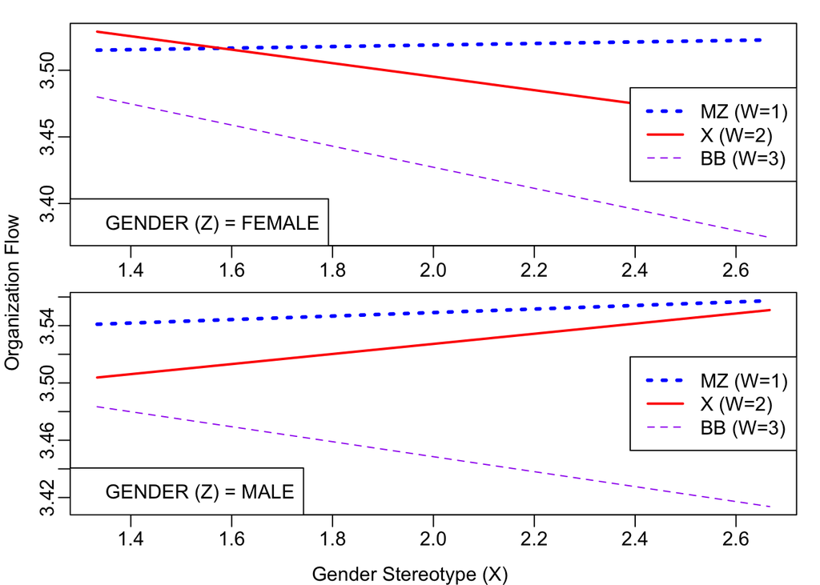

```r
oldp <- par(mfrow=c(2,1),mar=c(2,2,0,0),oma=c(1,1,1,1),mgp=c(5,0.5,0))

x <- c(1.3333, 2.1111, 2.6667, 1.3333, 2.1111, 2.6667, 1.3333, 2.1111, 2.6667)
w <- c(1,1,1,2,2,2,3,3,3)
y_female <- c(3.5151, 3.5196, 3.5228, 3.5290, 3.4896, 3.4615, 3.4800, 3.4184, 3.3745)
y_male <- c(3.5410, 3.5505, 3.5574, 3.5038, 3.5312, 3.5509, 3.4834, 3.4427, 3.4137)

legend.txt<-c("MZ (W=1)","X (W=2)", "BB (W=3)")
for (i in 0:1){
  if (i==0)
{y <- y_female
legend2.txt<-c("GENDER (Z) = FEMALE")}
  if (i==1)
{y <- y_male
legend2.txt<-c("GENDER (Z) = MALE")}
  plot(y=y,x=x,col="white",cex=1.5)
  lines(x[w==1],y[w==1],lty=3,lwd=3,col="blue")
  lines(x[w==2],y[w==2],lty=1,lwd=2,col="red")
  lines(x[w==3],y[w==3],lty=2,lwd=1,col="purple")
  legend("right",legend=legend.txt,lty=c(3,1,2),lwd=c(3,2,1), col=c("blue","red", "purple"))
  legend("bottomleft",legend=legend2.txt)
box}
mtext("Gender Stereotype (X)",side=1,outer=TRUE)
mtext("Organization Flow",side=2,outer=TRUE)
```

아니 근데 웬걸 X세대의 경우 성차가 있는 것 같기도 한데? X세대 남자는 평등하지 않은(남성중심적) 성 관념 인식을 가질수록 조직몰입도가 증가하는걸? 아주 재밌는 해석이 나타났다. 하지만 Int_6이 아깝게 유의하지 않았으므로 (p = .08) 이를 적극적으로 어필하지는 못하겠지만… 짧게 언급 정도 가능하려나 모르겠네

#### 2. 두 번째 회귀식

Y ~ X + M + W1 + W2 + XW1 + XW2 + Z + XZ + W1Z + W2Z + XW1Z + XW2Z

```
***********************************************************************
Outcome Variable: worksat

Model Summary:
          R      R-sq       MSE         F       df1       df2         p
     0.7594    0.5767    0.1262 1090.3278   12.0000 9603.0000    0.0000

Model:
             coeff        se         t         p      LLCI      ULCI
constant    1.0780    0.0365   29.5496    0.0000    1.0065    1.1495
gen_avg    -0.0182    0.0149   -1.2188    0.2230   -0.0474    0.0111
orgflow     0.7368    0.0065  113.6568    0.0000    0.7241    0.7495
W1          0.1212    0.0440    2.7509    0.0060    0.0348    0.2075
W2          0.1518    0.0500    3.0339    0.0024    0.0537    0.2498
Int_1      -0.0534    0.0222   -2.4014    0.0164   -0.0969   -0.0098
Int_2      -0.0558    0.0234   -2.3848    0.0171   -0.1016   -0.0099
gender     -0.0047    0.0393   -0.1204    0.9042   -0.0817    0.0723
Int_3      -0.0013    0.0194   -0.0667    0.9469   -0.0394    0.0368
Int_4      -0.0623    0.0601   -1.0358    0.3003   -0.1801    0.0556
Int_5      -0.0530    0.0704   -0.7530    0.4515   -0.1910    0.0850
Int_6       0.0260    0.0289    0.9000    0.3681   -0.0306    0.0826
Int_7       0.0292    0.0317    0.9206    0.3573   -0.0330    0.0913

Product terms key:
Int_1  :  gen_avg  x  W1
Int_2  :  gen_avg  x  W2
Int_3  :  gen_avg  x  gender
Int_4  :  W1  x  gender
Int_5  :  W2  x  gender
Int_6  :  gen_avg  x  W1  x  gender
Int_7  :  gen_avg  x  W2  x  gender

Test(s) of highest order unconditional interaction(s):
        R2-chng         F       df1       df2         p
X*W*Z    0.0001    0.5869    2.0000 9603.0000    0.5561
----------
Focal predictor: gen_avg (X)
      Moderator: generation (W)
      Moderator: gender (Z)

Data for visualizing the conditional effect of the focal predictor:
    gen_avg generation    gender   worksat
     1.3333     1.0000    0.0000    3.6343
     2.1111     1.0000    0.0000    3.6202
     2.6667     1.0000    0.0000    3.6101
     1.3333     1.0000    1.0000    3.6279
     2.1111     1.0000    1.0000    3.6128
     2.6667     1.0000    1.0000    3.6019
     1.3333     2.0000    0.0000    3.6844
     2.1111     2.0000    0.0000    3.6287
     2.6667     2.0000    0.0000    3.5890
     1.3333     2.0000    1.0000    3.6503
     2.1111     2.0000    1.0000    3.6139
     2.6667     2.0000    1.0000    3.5878
     1.3333     3.0000    0.0000    3.7118
     2.1111     3.0000    0.0000    3.6542
     2.6667     3.0000    0.0000    3.6132
     1.3333     3.0000    1.0000    3.6912
     2.1111     3.0000    1.0000    3.6554
     2.6667     3.0000    1.0000    3.6298
```

> **해석 Guide**
> - 오… 성별을 추가해버리니 성 관념 인식 -> 직무만족도로 가는 직접효과의 유의성이 사라졌다. 성별이 없을 땐 유의하던게 성별을 넣으니 유의하지 않아졌다? 이것은 무슨 의미이겠는가?
> - 그렇지만 Ind_1, Ind_2 여전히 유의하다. 즉 세대 간 상호작용이 들어갈 경우에는 유의한 효과가 나타나는 것으로, 여전히 ANOTHER MODEL의 결과처럼 해석이 가능하다.
> - 즉, MZ세대에 비해 X세대와 BB세대의 기울기가 더 유의하게 가파르다. 성 관념 인식이 평등하지 않을수록 직무 만족도의 감소 속도가 더 빠르다는 뜻.

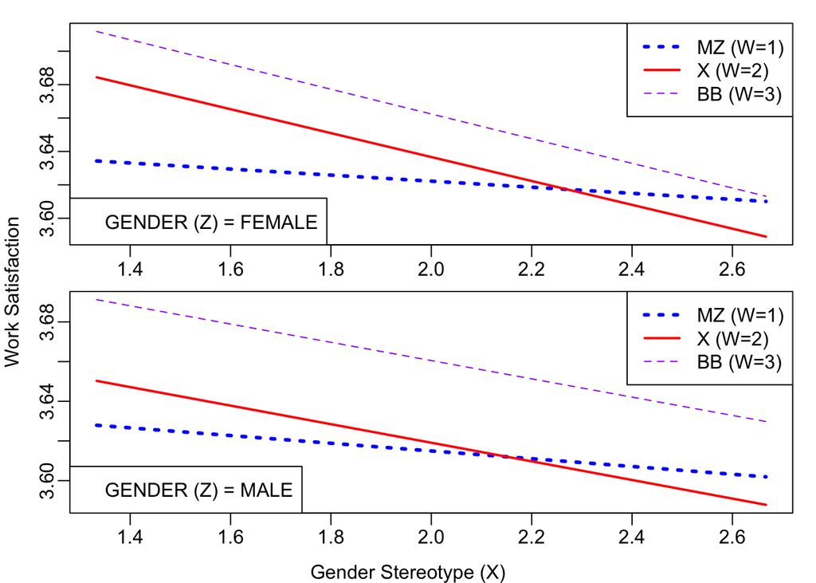

```r
oldp <- par(mfrow=c(2,1),mar=c(2,2,0,0),oma=c(1,1,1,1),mgp=c(5,0.5,0))

x <- c(1.3333, 2.1111, 2.6667, 1.3333, 2.1111, 2.6667, 1.3333, 2.1111, 2.6667)
w <- c(1,1,1,2,2,2,3,3,3)
y_female <- c(3.6343, 3.6202, 3.6101, 3.6844, 3.6287, 3.5890, 3.7118, 3.6542, 3.6132)
y_male <- c(3.6279, 3.6128, 3.6019, 3.6503, 3.6139, 3.5878, 3.6912, 3.6554, 3.6298)

legend.txt<-c("MZ (W=1)","X (W=2)", "BB (W=3)")
for (i in 0:1){
  if (i==0)
{y <- y_female
legend2.txt<-c("GENDER (Z) = FEMALE")}
  if (i==1)
{y <- y_male
legend2.txt<-c("GENDER (Z) = MALE")}
  plot(y=y,x=x,col="white",cex=1.5)
  lines(x[w==1],y[w==1],lty=3,lwd=3,col="blue")
  lines(x[w==2],y[w==2],lty=1,lwd=2,col="red")
  lines(x[w==3],y[w==3],lty=2,lwd=1,col="purple")
  legend("topright",legend=legend.txt,lty=c(3,1,2),lwd=c(3,2,1), col=c("blue","red", "purple"))
  legend("bottomleft",legend=legend2.txt)
box}
mtext("Gender Stereotype (X)",side=1,outer=TRUE)
mtext("Work Satisfaction",side=2,outer=TRUE)
```

직무만족도는 무조건 성 관념 인식이 평등하지 않을수록 감소한다는 일관적인 결과가 나타남. 그러나 이 계수가 유의하지 않은 건 이 기울기가 그렇게 가파르지 않다는 의미이기도 하다. 하지만 MZ세대와 나머지 X, BB세대의 기울기의 가파른 정도를 비교해보면, 비교적 완만한 MZ에 비해 X, BB는 가파른 편이기도 하다.

#### Bootstrapping을 통한 직접효과와 간접효과의 비교

```
Bootstrapping progress:
  |>>>>>>>>>>>>>>>>>>>>>>>>>>>>>>>>>>>>>>>>>>>>>>>>>>>>>>>>>>>>>>| 100%

**************** DIRECT AND INDIRECT EFFECTS OF X ON Y ****************

Conditional direct effect(s) of X on Y:
  generation    gender    effect        se         t         p      LLCI      ULCI
      1.0000    0.0000   -0.0182    0.0149   -1.2188    0.2230   -0.0474    0.0111
      1.0000    1.0000   -0.0195    0.0125   -1.5627    0.1182   -0.0439    0.0050
      2.0000    0.0000   -0.0715    0.0165   -4.3403    0.0000   -0.1038   -0.0392
      2.0000    1.0000   -0.0468    0.0136   -3.4514    0.0006   -0.0735   -0.0202
      3.0000    0.0000   -0.0739    0.0180   -4.1036    0.0000   -0.1093   -0.0386
      3.0000    1.0000   -0.0460    0.0174   -2.6430    0.0082   -0.0802   -0.0119

Conditional indirect effects of X on Y:

INDIRECT EFFECT:

gen_avg    ->    orgflow    ->    worksat

  generation    gender    Effect    BootSE  BootLLCI  BootULCI
      1.0000    0.0000    0.0043    0.0182   -0.0324    0.0398
      1.0000    1.0000    0.0091    0.0147   -0.0194    0.0382
      2.0000    0.0000   -0.0373    0.0192   -0.0748    0.0008
      2.0000    1.0000    0.0260    0.0158   -0.0049    0.0569
      3.0000    0.0000   -0.0583    0.0219   -0.1012   -0.0143
      3.0000    1.0000   -0.0385    0.0215   -0.0800    0.0047

******************** ANALYSIS NOTES AND ERRORS ************************

Level of confidence for all confidence intervals in output: 95

Number of bootstraps for percentile bootstrap confidence intervals: 5000
```

> **해석 Guide**
> - X세대와 BB세대의 경우 성 관념 인식 -> 직무 만족도 Direct Effect가 모두 유의했다. 즉, 평등하지 않은 성 관념 인식을 가질수록 직무 만족도가 감소한다.
> - 그런데 계수 차이를 보면 생각보다 기성 세대에서 성별 차이가 괘 나타나는 것 같이 보이는데…? 아슬아슬하게 유의하지가 않네. 저기 유의하기만 하면 시사점이 상당한데… 진짜 아슬아슬하게 안 나오는게 너무 아쉽네…
> - Indirect Effect의 경우 BB세대 여성에게서만 유의하게 나타났다. 즉, BB세대 여성의 경우 평등하지 않은 가치관을 가질수록 직무 몰입도가 낮아지고(-) 이는 곧 직무 만족도의 저하(+)로 이어지게 된다.
> - 따라서, BB세대 여성에게서만 부분 매개효과(Partial Mediation Effect)가 발생, 나머지는 발생하지 않았다.